# Lab 1 Forecasting with ARIMA and ETS models

Team 3: Ben Mahklouf, Tina Tao, and Emma Christman

#Initial Plan and What Actually Happened We will compare the accuracy of ARIMA models in yearly vs. monthly data, answering the question: Is the accuracy of monthly or yearly data better? To do this we will look only at the Washington data. To begin, we will test the stationarity of the yearly data and the monthly data.

If either are not stationary, we will use differencing to make them stationary for the purposes of this analysis. After the data are stationary, we will fit an ARIMA and ETS model to the monthly data using AutoARIMA on the earliest 80% of the data. This will allow use to compare the accuracy of the ARIMA model in predicting the last 20% of the data to the actual data. After this is done, we will do the same to the yearly data. Then, we can use the accuracy function to compare the two methods.

#Question Addressed 1) Is an ARIMA model and/or an ETS model adequate for using monthly data and yearly data? 2) Is the accuracy of forecasting with monthly data or yearly data “better”?

# Step1, load data and filter to Washington with basic plots

```r
# Seperate the monthly and yearly data
library(atsalibrary) # This is ALL the data
```

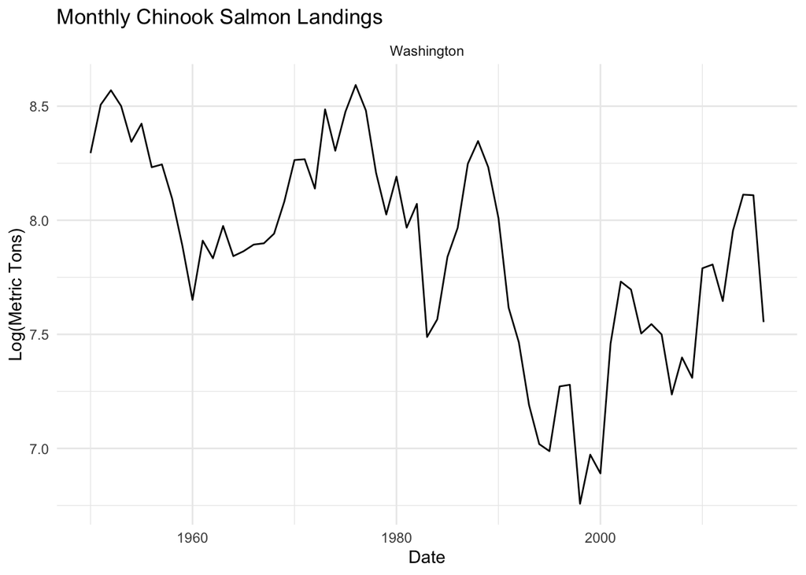

```r
# This is the monthly data
chinook.month <- chinook.month %>%
  mutate(Date = as.Date(paste(Year, Month, "01", sep = "-"), format = "%Y-%b-%d"))

chinook.month <- chinook.month %>%
  filter(State %in% c("WA"))

chinook.year <- chinook.year

chinook.year_filtered <- chinook.year %>%
  filter(State == "Washington")

# Quick plot of year

ggplot(chinook.year_filtered, aes(x = Year, y = log.metric.tons)) +
  geom_line() +
  facet_wrap(~ State, ncol = 1) +  # 3 panels vertically
  labs(title = "Monthly Chinook Salmon Landings",
       x = "Date",
       y = "Log(Metric Tons)") +
  theme_minimal()
```

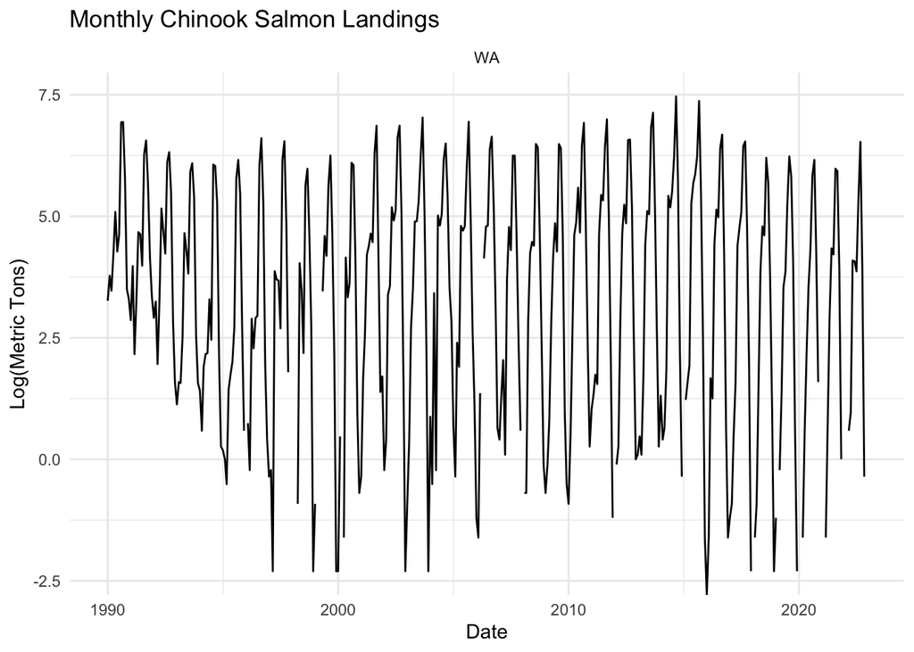

```r
# Quick plot of month

ggplot(chinook.month, aes(x = Date, y = log.metric.tons)) +
  geom_line() +
  facet_wrap(~ State, ncol = 1) +  # 3 panels vertically
  labs(title = "Monthly Chinook Salmon Landings",
       x = "Date",
       y = "Log(Metric Tons)") +
  theme_minimal()
```

# Step2, check stationarity and differencing

```r
yearly <- chinook.year_filtered %>%
  arrange(Year) %>%
  pull(log.metric.tons)

yearly_ts <- ts(yearly, start = 1950, end = 2016, frequency = 1)


monthly<- chinook.month %>%
  #change log metric tons inf to NA
  mutate(log.metric.tons = ifelse(log.metric.tons == Inf, NA, log.metric.tons)) %>%
  mutate(log.metric.tons = ifelse(log.metric.tons == -Inf, NA, log.metric.tons)) %>%
  filter(!is.na(log.metric.tons))

monthly <- monthly %>%
  arrange(Date) %>%
  pull(log.metric.tons)

# Are there NAs in monthly
# remove NA

monthly_ts <- ts(monthly, start = c(1990,1), frequency = 12)


##############################

# Check the need to difference the data

adf.test(yearly_ts)
```

```
##
##  Augmented Dickey-Fuller Test
##
## data:  yearly_ts
## Dickey-Fuller = -2.5627, Lag order = 4, p-value = 0.3467
## alternative hypothesis: stationary
```

```r
# Augmented Dickey-Fuller Test
#
# data:  yearly_ts
# Dickey-Fuller = -2.5627, Lag order = 4, p-value = 0.3467
# alternative hypothesis: stationary

# Not stationary, p value greater than .01


adf.test(monthly_ts)
```

```
##
##  Augmented Dickey-Fuller Test
##
## data:  monthly_ts
## Dickey-Fuller = -9.6198, Lag order = 7, p-value = 0.01
## alternative hypothesis: stationary
```

```r
# Augmented Dickey-Fuller Test
#
# data:  monthly_ts
# Dickey-Fuller = -9.6198, Lag order = 7, p-value = 0.01
# alternative hypothesis: stationary

# These data ARE Stationary

#############################

# We can run the ndiff to see how many differences we would need to get to stationarity

ndiffs(yearly_ts)
```

```
## [1] 1
```

```r
# [1], we need to difference ONCE, we expect the middle number in autoarima to be 1
```

### Step 3, explore correlation and autocorrelation using ACF and PACF

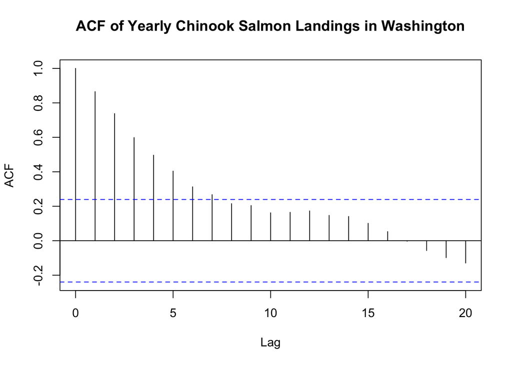

```r
acf(yearly_ts, lag.max = 20, main = "ACF of Yearly Chinook Salmon Landings in Washington")
```

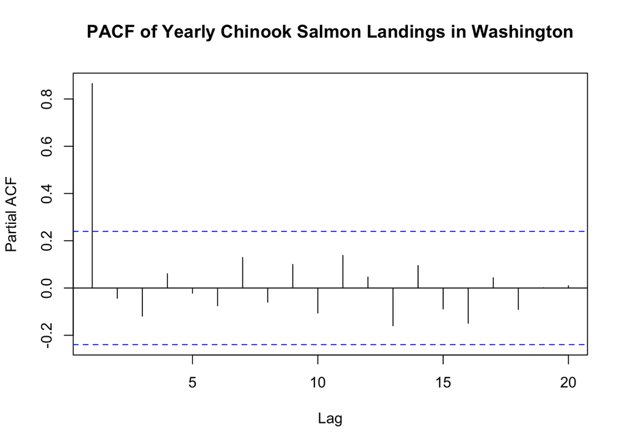

```r
# The ACF plot shows a tails off structure
pacf(yearly_ts, lag.max = 20, main = "PACF of Yearly Chinook Salmon Landings in Washington")
```